# 2025 Veo Atlas

### Land Uses and Parking

More striking is the land uses (if parked on private property)

```r
#Parking first
#Across the C-U Market

park <- original_dropoffs |>
  select(1, 17, 19, 20) |>
  mutate(`Other ROW (End)` = case_when(`Other ROW (End)` == 'Yes' ~ 1)) |>
  mutate(`Private Property (End)` = case_when(`Private Property (End)` == 'Yes' ~ 1)) |>
  mutate(`Road ROW (End)` = case_when(`Road ROW (End)` == 'Yes' ~ 1)) |>
  summarize(`Parked on ROW - Other` = sum(`Other ROW (End)`, na.rm = TRUE), `Parked on ROW - Road` = sum(`Road ROW (End)`, na.rm = TRUE), `Parked on Private Property` = sum(`Private Property (End)`, na.rm = TRUE))

parking_tbl <- park |>
  t() |>
  as.data.frame() |>
  tibble::rownames_to_column("Parking Location") |>
  rename(Trips = V1) |>
  arrange(desc(Trips)) |>
  gt() |>
  fmt_integer(columns = "Trips", sep_mark = ",") |>
  cols_add(Bar = Trips, .after = Trips) %>%
  gt_plt_bar(column = "Bar",
                 color = "#184860FF") |>
  cols_label(Bar = "") |>
  opt_table_font(font = "Noto Sans") |>
  opt_align_table_header(align = "left") |>
  tab_header(title = "2025 Bike Share Parking Locations") |>
  tab_style(style = cell_text(font = "Noto Serif", weight = 800, size = "big"),
            locations = cells_title()) |>
  tab_style(style = cell_text(font = "Noto Serif", weight = 600, size = "small", transform = "uppercase"),
            locations = cells_column_labels())

parking_tbl
```

2025 Bike Share Parking Locations

| Parking Location | Trips |  |
| --- | --- | --- |
| Parked on Private Property | 212,801 |  |
| Parked on ROW - Other | 84,907 |  |
| Parked on ROW - Road | 43,690 |  |

```r
gtsave(parking_tbl, "parking.png", path = "G:/Transportation and Infrastructure/Bicycles/Bike Share/2026 Study Session and License/veo_atlas/outputs")
```

If the bike was parked on private property, what was the top land uses?

Let’s simplify land use to the first digit.

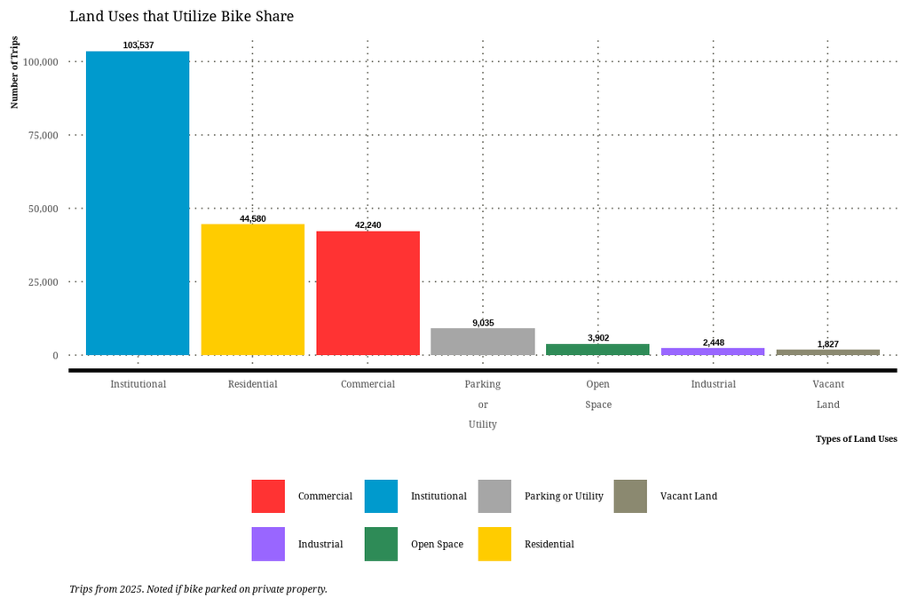

```r
lu_color <- c('Residential' = '#FFCC00', 'Commercial' = '#FF3333', 'Industrial' = '#9966FF', 'Institutional' = 'deepskyblue3', 'Open Space' = 'seagreen', 'Parking or Utility' = 'gray65', 'Vacant Land' = 'lemonchiffon4')

land_count <- original_pickup %>%
  filter(`Private Property (Start)` == "Yes") |>
  select(1, 9, 10:16) |>
  rename(code = `Land Use Code (Start)`) |>
  mutate(Land_Use = as.factor(case_when(code >= 2000 & code < 3000 ~ "Residential",
                              code >= 3000 & code < 4000 ~ "Commercial",
                              code >= 4000 & code < 5000 ~ "Industrial",
                              code >= 5000 & code < 6000 ~ "Institutional",
                              code >= 6000 & code < 7000 ~ "Parking or Utility",
                              code >= 7000 & code < 8000 ~ "Open Space",
                              code >= 8000 & code < 9000 ~ "Vacant Land"))) |>
  relocate(Land_Use, .before = "Municipality (Start)") |>
  group_by(Land_Use) |>
  count(Land_Use) |>
  rename(Trips_Ended = n) |>
  filter(Land_Use != "NA") |>
  arrange(desc(Trips_Ended))


bar_lu <- land_count %>%
  ggplot(aes(x= reorder(Land_Use, -Trips_Ended), y = Trips_Ended, fill = Land_Use)) +
  geom_bar(position = "dodge", stat = "identity") +
  scale_fill_manual(values = lu_color) +
  scale_y_continuous(labels = scales::label_comma()) +
  scale_x_discrete(labels = label_wrap_gen(width = 10, multi_line = TRUE)) +
  labs(title = "Land Uses that Utilize Bike Share",
       caption = "Trips from 2025. Noted if bike parked on private property.",
       x = "Types of Land Uses",
       y = "Number of Trips") +
  geom_text(aes(label = scales::comma(Trips_Ended)),
            color = "black",
            vjust = -0.5,
            size = 3,
            fontface = "bold") +
  theme_lily() +
  theme(plot.caption = element_text(hjust = 0,
                                    face = "italic"),
        axis.text.x = element_text(angle = 0,
                                   hjust = 0.5),
        legend.position = "bottom")

bar_lu
```

Let’s remove Campus and Campustown….

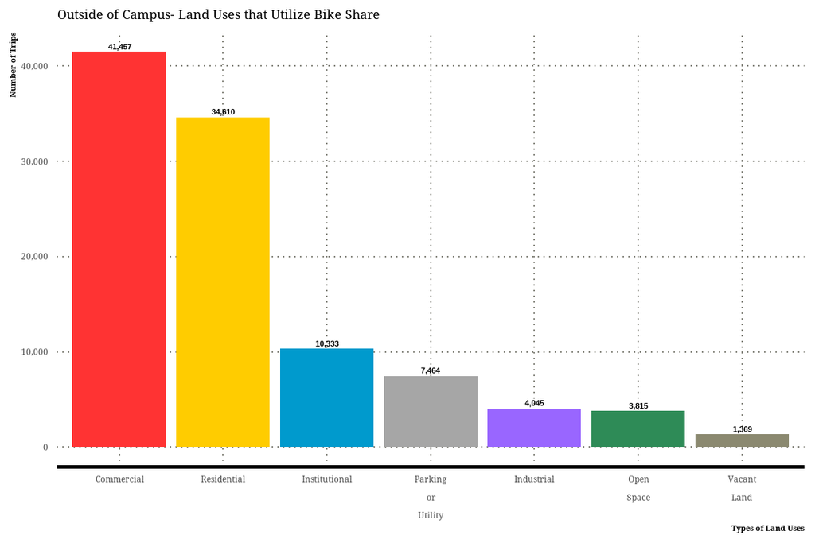

```r
land_count_no_campus <- original_pickup %>%
  left_join(original_dropoffs, by = "OBJECTID") |>
  filter(`Private Property (Start)` == "Yes") |>
  filter(is.na(`Special District (Start)`) | `Special District (Start)` != "Campus" & `Special District (Start)` != "Campustown") |>
  select(1, 9, 10:16, 66:76) |>
  rename(code = `Land Use Code (Start)`, code2 = `Land Use Code (End)`) |>
  mutate(Land_Use = as.factor(case_when(code >= 2000 & code < 3000 ~ "Residential",
                              code >= 3000 & code < 4000 ~ "Commercial",
                              code >= 4000 & code < 5000 ~ "Industrial",
                              code >= 5000 & code < 6000 ~ "Institutional",
                              code >= 6000 & code < 7000 ~ "Parking or Utility",
                              code >= 7000 & code < 8000 ~ "Open Space",
                              code >= 8000 & code < 9000 ~ "Vacant Land"))) %>%
    mutate(Land_Use2 = as.factor(case_when(code2 >= 2000 & code2 < 3000 ~ "Residential",
                              code2 >= 3000 & code2 < 4000 ~ "Commercial",
                              code2 >= 4000 & code2 < 5000 ~ "Industrial",
                              code2 >= 5000 & code2 < 6000 ~ "Institutional",
                              code2 >= 6000 & code2 < 7000 ~ "Parking or Utility",
                              code2 >= 7000 & code2 < 8000 ~ "Open Space",
                              code2 >= 8000 & code2 < 9000 ~ "Vacant Land"))) %>%
  relocate(Land_Use, Land_Use2, .before = "Municipality (Start)") |>
  select(1:3) |>
  pivot_longer(c(Land_Use, Land_Use2), names_to = "PickupDropoff", values_to = "Land_Use") |>
  group_by(Land_Use) |>
  count(Land_Use) |>
  rename(Trips_Ended = n) |>
  filter(Land_Use != "NA") |>
  arrange(desc(Trips_Ended))

bar_lu_no_campus <- land_count_no_campus %>%
  ggplot(aes(x= reorder(Land_Use, -Trips_Ended), y = Trips_Ended, fill = Land_Use)) +
  geom_bar(position = "dodge", stat = "identity") +
  scale_fill_manual(values = lu_color) +
  scale_y_continuous(labels = scales::label_comma()) +
  scale_x_discrete(labels = label_wrap_gen(width = 10, multi_line = TRUE)) +
  labs(title = "Outside of Campus- Land Uses that Utilize Bike Share",
       x = "Types of Land Uses",
       y = "Number of Trips") +
  geom_text(aes(label = scales::comma(Trips_Ended)),
            color = "black",
            vjust = -0.5,
            size = 3,
            fontface = "bold") +
  theme_lily() +
  theme(plot.caption = element_text(hjust = 0,
                                    face = "italic"),
        axis.text.x = element_text(angle = 0,
                                   hjust = 0.5),
        legend.position = "none")

bar_lu_no_campus
```

Clearly destinations! See a friend at their home or a business, go to work or home, etc.

```r
# waffles need a very simple data structure to map! Pretty fun.

waffle_res <- original_pickup |>
  left_join(original_dropoffs, by = "OBJECTID") |>
  rename(code = `Land Use Code (Start)`, code2 = `Land Use Code (End)`) |>
  select(1, 12, 17, 68, 73) |>
  filter(`Private Property (Start)` == "Yes" | `Private Property (End)` == "Yes") |>
  pivot_longer(c(code, code2), names_to = "PickupDropoff", values_to = "Land_Use") |>
  select(1, 5) |>
  filter(Land_Use != "NULL")

# Some of the codes have more than one code and they are separate by comma. Let's preserve them and clean them separately and combine.

waffle_res_removed <- waffle_res |>
  filter((nchar(Land_Use) > 4)) |>
  separate_longer_delim(cols = Land_Use,
                        delim = ",") |>
  filter(Land_Use != "NULL")

waffle_res2 <- waffle_res |>
  filter(!(nchar(Land_Use) > 4)) |>
  rbind(waffle_res_removed) |>
  mutate(Land_Use = as.numeric(Land_Use)) |>
  filter(Land_Use >= 2000, Land_Use < 3000) |>
  group_by(Land_Use) |>
  count(Land_Use) |>
  rename(Trips = n) |>
  filter(Land_Use != "NA") |>
  arrange(desc(Trips)) |>
  mutate(Land_Use_Label = as.factor(case_when(Land_Use == 2100 ~ "Detached Residential",
                              Land_Use == 2200 ~ "Attached Residential",
                              Land_Use == 2300 ~ "Multifamily Residential",
                              Land_Use == 2310 ~ "Multifamily Residential Conversion",
                              Land_Use == 2400 ~ "Group Residential",
                              Land_Use == 2500 ~ "Mobile Home"))) |>
  ungroup()

#upon seeing the results, I need to combine multifamily conversion. This is just planning jargon.

combine_res <- waffle_res2 |>
  filter(Land_Use %in% c(2300, 2310)) |>
  summarize(Land_Use = 2300,
            Trips = sum(Trips),
            Land_Use_Label = "Multifamily Residential") |>
  group_by(Land_Use, Land_Use_Label) |>
  summarize(Trips = sum(Trips)) |>
  ungroup()
waffle_res3 <- waffle_res2 |>
  filter(Land_Use != 2310, Land_Use != 2300) |>
  bind_rows(combine_res) |>
  arrange(desc(Trips))
```

Time to make the waffle! It is basically a glorified pie chart but I really don’t like pie charts.For reasons that the waffle does not solve.

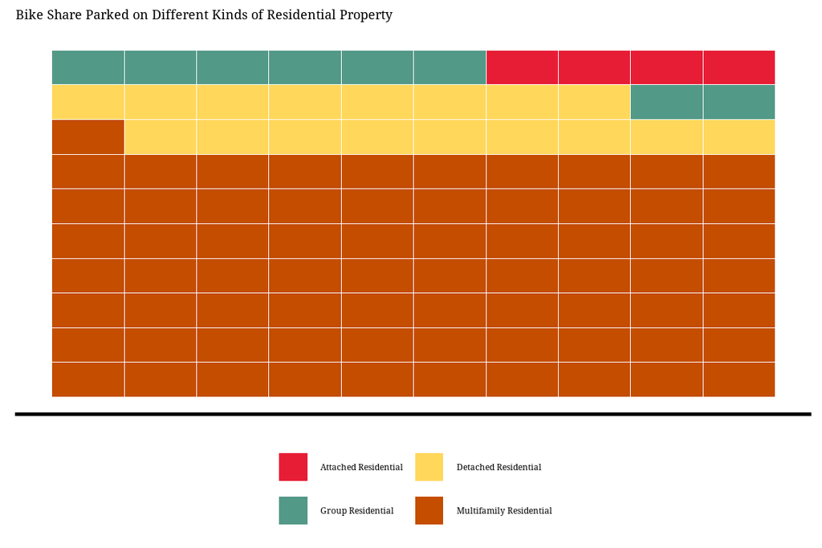

```r
res_color <- c('Detached Residential' = '#ffd75b', 'Attached Residential' = '#e71d36', 'Multifamily Residential' = '#c44d00', 'Multifamily Residential Conversion' = '#000000', 'Group Residential' = '#539987', 'Mobile Home' = '#043')

res_waffle <- waffle_res3 |>
  ggplot(aes(fill = Land_Use_Label, values = Trips)) +
  geom_waffle(nrows = 100, size = 0.2, make_proportional = TRUE, color = "white", flip = TRUE) +
  scale_fill_manual(values = res_color) +
  labs(title = "Bike Share Parked on Different Kinds of Residential Property") +
  theme_lily() +
  theme_enhance_waffle() +
  theme(panel.grid.major.x = element_blank(),
        panel.grid.major.y = element_blank(),
        legend.position = "bottom",
        legend.box = "horizontal") +
  guides(fill = guide_legend(nrow = 2,
                             byrow = TRUE,
                             label.hjust = 0,
                             label.str_wrap = 15))

res_waffle
```

```r
waffle_tbl <- waffle_res2 |>
  rename(`Land Use` = Land_Use_Label) |>
  ungroup() |>
  mutate(Percent = (Trips/sum(Trips))*100) |>
  select(!Land_Use) |>
  relocate(`Land Use`, .before = Trips) |>
  gt() |>
  fmt_integer(columns = "Trips", sep_mark = ",") |>
  cols_add(Bar = Percent, .after = Percent) |>
  fmt_percent(columns = Percent,
              decimals = 1,
              scale_values = FALSE) |>
  gt_plt_bar_pct(column = Bar,
                 scaled = TRUE,
                 fill = "#184860FF",
                 background = "#D8D8D8FF") |>
  opt_table_font(font = "Noto Serif") |>
  tab_header(title = "2025 Veo Parking on Residential Property by Type") |>
  tab_style(style = cell_text(font = "Noto Serif", weight = 800, size = "big"),
            locations = cells_title()) |>
  tab_style(style = cell_text(font = "Noto Serif", weight = 600, size = "small"),
            locations = cells_column_labels()) |>
  tab_options(table.background.color = "transparent",
              heading.background.color = "transparent",
              column_labels.background.color = "transparent")

waffle_tbl
```

2025 Veo Parking on Residential Property by Type

| Land Use | Trips | Percent | Bar |
| --- | --- | --- | --- |
| Multifamily Residential | 63,305 | 68.5% |  |
| Detached Residential | 15,273 | 16.5% |  |
| Group Residential | 7,157 | 7.7% |  |
| Attached Residential | 3,531 | 3.8% |  |
| Multifamily Residential Conversion | 2,799 | 3.0% |  |
| Mobile Home | 361 | 0.4% |  |

```r
gtsave(waffle_tbl, "residential types parking.png", path = "G:/Transportation and Infrastructure/Bicycles/Bike Share/2026 Study Session and License/veo_atlas/outputs")
```

Very multifamily.